# BTS 510 Lab 10

```r
set.seed(12345)
library(tidyverse)
library(Stat2Data)
theme_set(theme_classic(base_size = 16))
```

## 1 Learning objectives

- **Run models** with interaction effects to assess conditional effects of predictors
- **Probe** interaction models to fully understand all effects

## 2 Data

- `ICU` data from the **Stat2Data** package: $n$ = 200
  - `ID`: Patient ID code
  - `Survive`: 1 = patient survived to discharge or 0 = patient died
  - `Age`: Age (in years)
  - `AgeGroup`: 1 = young (under 50), 2 = middle (50-69), 3 = old (70+)
  - `Sex`: 1 = female or 0 = male
  - `Infection`: 1 = infection suspected or 0 = no infection
  - `SysBP`: Systolic blood pressure (in mm of Hg)
  - `Pulse`: Heart rate (beats per minute)
  - `Emergency`: 1 = emergency admission or 0 = elective admission

## 3 Analysis

- Replicate and extend the analysis from the lecture
  - `Age`, `Emergency`, and their interaction predict `Pulse`
  - Be sure to mean center `Age` for interpretability.

## 4 Tasks

- Model 1: `Pulse ~ Age + Emergency`
- Model 2: `Pulse ~ Age + Emergency + Age*Emergency`

```r
library(Stat2Data)
data(ICU)
ICU <- ICU %>% mutate(AgeC = Age - mean(Age, na.rm = TRUE))
m1 <- lm(data = ICU, Pulse ~ AgeC + Emergency)
m2 <- lm(data = ICU, Pulse ~ AgeC + Emergency + AgeC*Emergency)
summary(m1)
```

```
Call:
lm(formula = Pulse ~ AgeC + Emergency, data = ICU)

Residuals:
   Min     1Q Median     3Q    Max
-63.10 -18.13  -3.56  17.27  88.73

Coefficients:
            Estimate Std. Error t value Pr(>|t|)
(Intercept) 90.50761    3.68515  24.560  < 2e-16 ***
AgeC         0.09723    0.09527   1.021  0.30873
Emergency   11.45223    4.31849   2.652  0.00866 **
---
Signif. codes:  0 '***' 0.001 '**' 0.01 '*' 0.05 '.' 0.1 ' ' 1

Residual standard error: 26.48 on 197 degrees of freedom
Multiple R-squared:  0.03582,   Adjusted R-squared:  0.02603
F-statistic: 3.659 on 2 and 197 DF,  p-value: 0.02753
```

```r
summary(m2)
```

```
Call:
lm(formula = Pulse ~ AgeC + Emergency + AgeC * Emergency, data = ICU)

Residuals:
    Min      1Q  Median      3Q     Max
-63.557 -16.917  -3.928  16.011  86.799

Coefficients:
               Estimate Std. Error t value Pr(>|t|)
(Intercept)     94.4823     3.8476  24.556  < 2e-16 ***
AgeC            -0.5409     0.2323  -2.329  0.02088 *
Emergency        7.7539     4.4091   1.759  0.08020 .
AgeC:Emergency   0.7612     0.2537   3.001  0.00304 **
---
Signif. codes:  0 '***' 0.001 '**' 0.01 '*' 0.05 '.' 0.1 ' ' 1

Residual standard error: 25.96 on 196 degrees of freedom
Multiple R-squared:  0.07817,   Adjusted R-squared:  0.06406
F-statistic:  5.54 on 3 and 196 DF,  p-value: 0.001137
```

1. Conduct a likelihood ratio test to compare the models. Report the results. Which model is preferred?

```r
logLik(m1)
```

```
'log Lik.' -937.5404 (df=4)
```

```r
logLik(m2)
```

```
'log Lik.' -933.0483 (df=5)
```

```r
-2*(logLik(m1) - logLik(m2))
```

```
'log Lik.' 8.984209 (df=4)
```

```r
anova(m1, m2, test = "LRT")
```

```
Analysis of Variance Table

Model 1: Pulse ~ AgeC + Emergency
Model 2: Pulse ~ AgeC + Emergency + AgeC * Emergency
  Res.Df    RSS Df Sum of Sq Pr(>Chi)
1    197 138115
2    196 132048  1      6067 0.002692 **
---
Signif. codes:  0 '***' 0.001 '**' 0.01 '*' 0.05 '.' 0.1 ' ' 1
```

- Model 2 (with the `AgeC*Emergency` interaction) is a better model than Model 1 (without the interaction), $\chi^2(1) = 8.98, p<.01$.
  - Significant LRT = more complicated model is better
2. Plot the simple slopes with the data points. What is the general pattern of results?
- **ggplot**

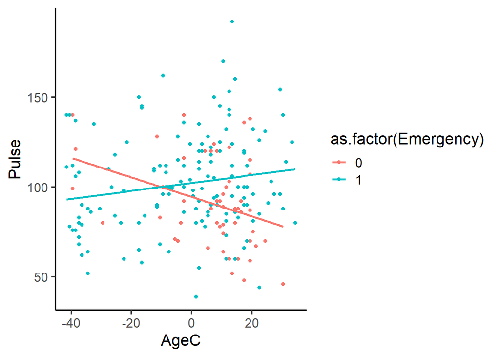

```r
ggplot(data = ICU, aes(x = AgeC, y = Pulse, group = Emergency)) +
  geom_point(aes(color = as.factor(Emergency))) +
  geom_smooth(method = "lm",
              se = FALSE,
              aes(color = as.factor(Emergency)))
```

- **interactions**

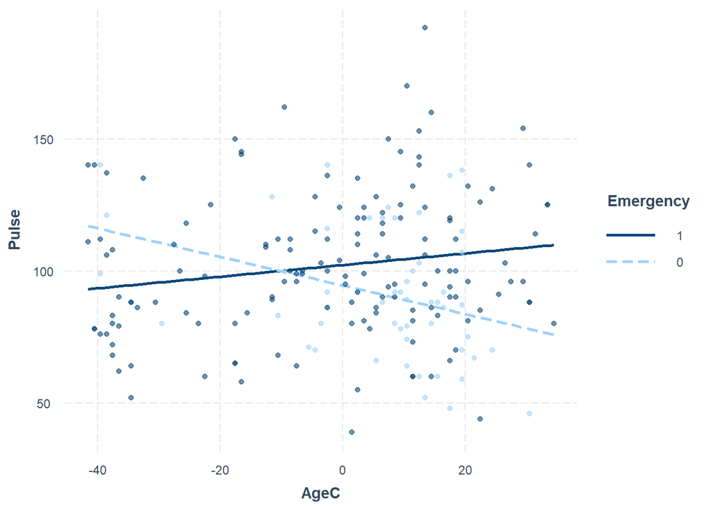

```r
library(interactions)
interact_plot(m2,
              pred = AgeC,
              modx = Emergency,
              plot.points = TRUE)
```

- It looks like the emergency admitted group increases pulse rate with age while the non-emergency admitted group decreases pulse with age.
3. Conduct simple slopes analysis and the Johnson-Neyman procedure. Report the findings, including test statistics, degrees of freedom, and $p$-values.

```r
sim_slopes(m2,
           pred = AgeC,
           modx = Emergency,
           johnson_neyman = FALSE)
```

```
SIMPLE SLOPES ANALYSIS

Slope of AgeC when Emergency = 0.00 (0):

   Est.   S.E.   t val.      p
------- ------ -------- ------
  -0.54   0.23    -2.33   0.02

Slope of AgeC when Emergency = 1.00 (1):

  Est.   S.E.   t val.      p
------ ------ -------- ------
  0.22   0.10     2.16   0.03
```

```
JOHNSON-NEYMAN INTERVAL

When AgeC is OUTSIDE the interval [-44.31, 1.06], the slope of Emergency is
p < .05.

Note: The range of observed values of AgeC is [-41.55, 34.45]
```

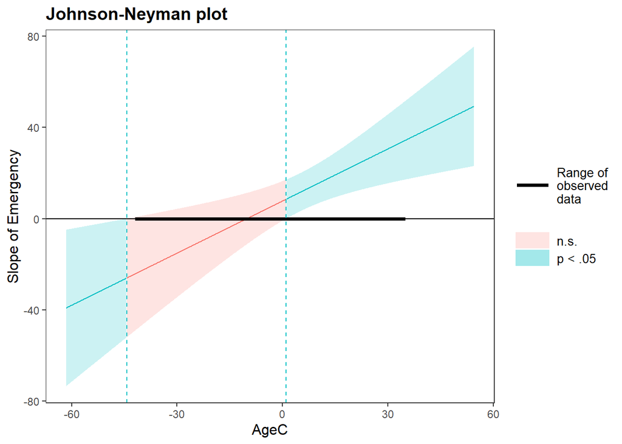

```r
johnson_neyman(m2,
               pred = Emergency,
               modx = AgeC,
               alpha = .05)
```

```r
mean(ICU$Age, na.rm = TRUE)
```

```
[1] 57.545
```

- Is the slope with respect to age significant for each group?
  - The slope with respect to age (`AgeC`) is significant and **negative** for non-emergency admissions (`Emergency` = 0); $b = -0.54, t(196) = -2.33, p=.02$.
  - The slope with respect to age (`AgeC`) is significant and **positive** for emergency admissions (`Emergency` = 1); $b = 0.22, t(196) = 2.16, p=.03$.
- For which values of age are the emergency groups different in pulse rate?
  - “When AgeC is OUTSIDE the interval [-44.31, 1.06], the slope of Emergency is p < .05”
  - When `AgeC` is **less than** -44.31 (`Age` = 57.545 - 44.31 = 13.235)
  - When `AgeC` is **greater than** 1.06 (`Age` = 57.545 + 1.06 = 58.605)
4. Conduct outlier analysis for the model. Are there observations with extreme values on the predictors or predicted values? Are there observations that change the findings? Briefly report your findings.

```r
library(broom)
library(car)
m2_aug <- augment(m2)
m2_aug <- m2_aug %>% mutate(esresid = rstudent(m2))
head(m2_aug)
```

```
# A tibble: 6 × 10
  Pulse   AgeC Emergency .fitted .resid    .hat .sigma    .cooksd .std.resid
  <int>  <dbl>     <int>   <dbl>  <dbl>   <dbl>  <dbl>      <dbl>      <dbl>
1    96  29.5          1   109.  -12.7  0.0223    26.0 0.00140       -0.496
2    88 -30.5          1    95.5  -7.51 0.0192    26.0 0.000417      -0.292
3    80   1.45         1   103.  -22.6  0.00701   26.0 0.00134       -0.872
4    70  19.5          0    84.0 -14.0  0.0329    26.0 0.00254       -0.547
5    90  18.5          1   106.  -16.3  0.0134    26.0 0.00136       -0.632
6   103  -3.55         1   101.    1.54 0.00683   26.0 0.00000613     0.0597
# ℹ 1 more variable: esresid <dbl>
```

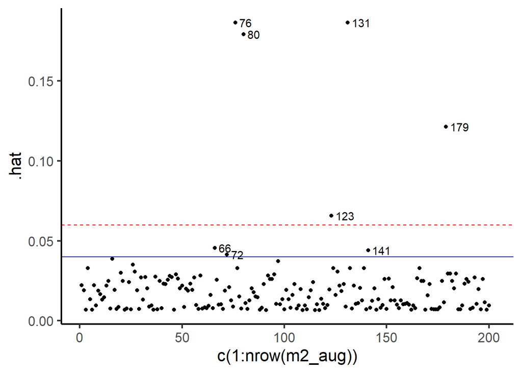

```r
ggplot(data = m2_aug,
       aes(x = c(1:nrow(m2_aug)),
           y = .hat)) +
  geom_point() +
  geom_hline(yintercept = 3*(3+1)/200,
             color = "red",
             linetype = "dashed") +
  geom_hline(yintercept = 2*(3+1)/200,
             color = "blue") +
  geom_text(aes(label=ifelse((.hat > 2*(3+1)/200),
                             rownames(m2_aug),
                             '')),
            hjust = 0, nudge_x = 2)
```

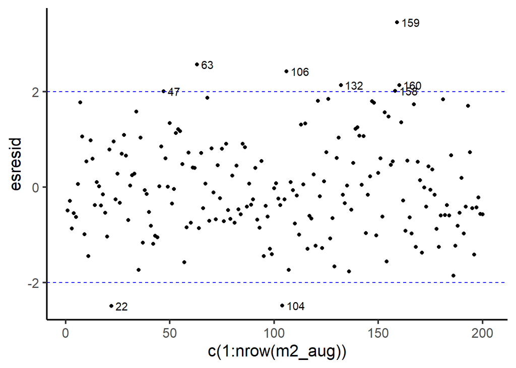

```r
ggplot(data = m2_aug,
       aes(x = c(1:nrow(m2_aug)),
           y = esresid)) +
  geom_point() +
  geom_hline(yintercept = 2,
             color = "blue",
             linetype = "dashed") +
  geom_hline(yintercept = -2,
             color = "blue",
             linetype = "dashed") +
  geom_text(aes(label=ifelse((esresid > 2),
                             rownames(m2_aug),
                             '')),
            hjust = 0, nudge_x = 2) +
  geom_text(aes(label=ifelse((esresid < -2),
                             rownames(m2_aug),
                             '')),
            hjust = 0, nudge_x = 2)
```

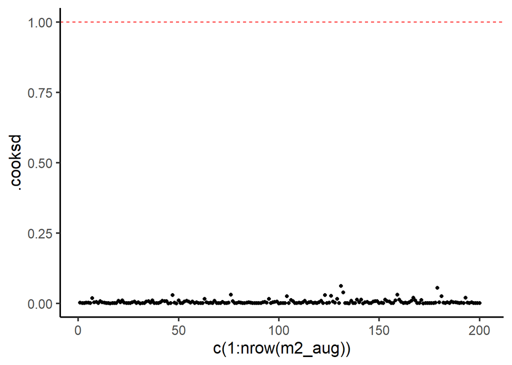

```r
ggplot(data = m2_aug,
       aes(x = c(1:nrow(m2_aug)),
           y = .cooksd)) +
  geom_point() +
  geom_hline(yintercept = 1,
             color = "red",
             linetype = "dashed") +
  geom_text(aes(label=ifelse((.cooksd > 1),
                             rownames(m2_aug),
                             '')),
            hjust = 0, nudge_x = 2)
```